# L05 Annotation & Positioning

Data Visualization (STAT 302)

Author

Yizhe Zhang

**TipGithub Repo Link**

To link to your github **repo**sitory, appropriately edit the example link below. Meaning replace `https://your-github-repo-url` with your github repo url. Suggest verifying the link works before submitting.

https://github.com/yzh349/Stat302

## Overview

The goal of this lab is to explore methods for annotating and positioning with `ggplot2` plots. This lab also utilizes `scale_*` to a greater degree which is part of our next reading. In fact, students may find going through/reading chapter [11 Colour scales and legends](https://ggplot2-book.org/scale-colour.html) useful.

## Datasets

We’ll be using the `blue_jays.rda`, `titanic.rda`, `Aus_athletes.rda`, and `tech_stocks.rda` datasets.

```r
# Load package(s)
library(tidyverse)
library(sf)
library(tidycensus)
library(mapview)
library(tigris)
library(geodata)
library(raster)
library(janitor)
library(maps)
library(viridis)
library(statebins)
library(ggrepel)
library(patchwork)
library(cowplot)
# Load data
load(file = "blue_jays.rda")
load(file = "titanic.rda")
load(file = "Aus_athletes.rda")
load(file = "tech_stocks.rda")
```

## Exercises

Complete the following exercises.

## Exercise 1

Using the `blue_jays.rda` dataset, recreate the following graphic as precisely as possible.

*Hints:*

- Transparency is 0.8
- Point size 2
- Create a `label_info` dataset that is a subset of original data, just with the 2 birds to be labeled
- Shift label text horizontally by 0.5
- See ggplot2 textbook 8.3 building custom annotations
- Annotation size is 4
- Classic theme

**Tip**

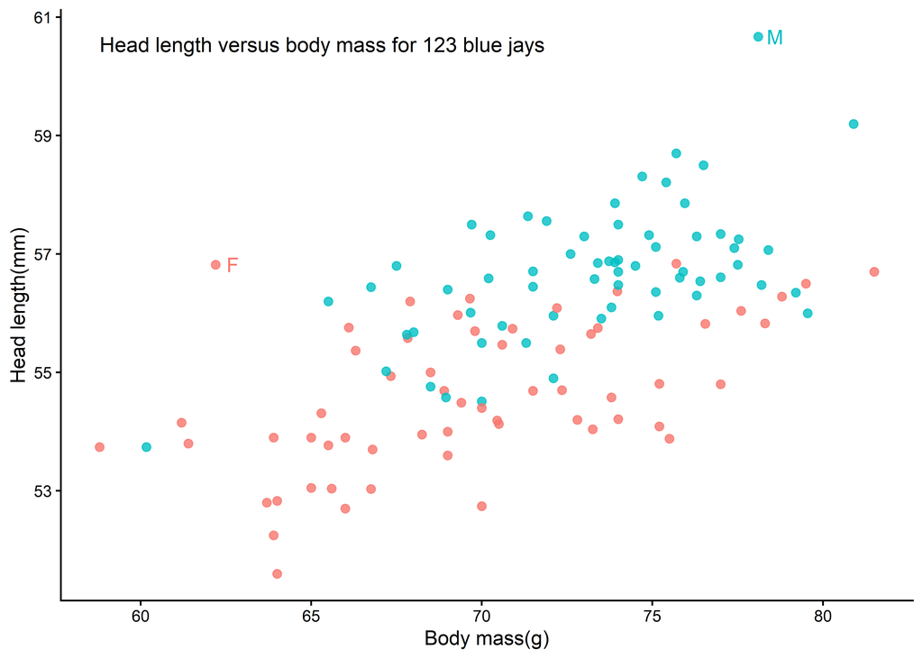

```r
yrng <- range(blue_jays$Head)
xrng <- range(blue_jays$Mass)
label_info <- blue_jays %>%
  filter(BirdID %in% c("702-90567", "1142-05914"))

ggplot(data = blue_jays, mapping = aes(x = Mass, y= Head, color = KnownSex)) +
  geom_point(size = 2, alpha = 0.8, show.legend = FALSE) +
  geom_text(data = label_info, aes(label = KnownSex), nudge_x = 0.5, show.legend = FALSE) +
  xlab("Body mass(g)") +
  ylab("Head length(mm)") +
  annotate("text", x = xrng[1], y = yrng[2], label = "Head length versus body mass for 123 blue jays", hjust = 0, vjust = 1, size = 4) +
  theme_classic()
```

## Exercise 2

Using the `tech_stocks` dataset, recreate the following graphics as precisely as possible. Use the column `price_indexed`.

### Plot 1

*Hints:*

- Create a `label_info` dataset that is a subset of original data, just containing the last day’s information for each of the 4 stocks
- serif font
- Annotation size is 4

**TipSolution**

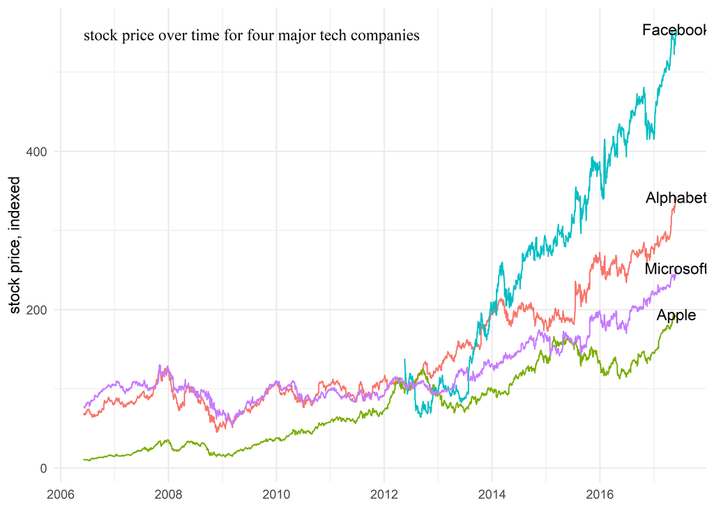

```r
label_info <- tech_stocks %>%
  arrange(desc(date)) %>%
  distinct(company, .keep_all = TRUE)

yrng <- range(tech_stocks$price_indexed)
xrng <- range(tech_stocks$date)
caption <- "stock price over time for four major tech companies"
ggplot(tech_stocks, aes(x = date, y = price_indexed)) +
  geom_line(aes(color = company), show.legend = FALSE)+
  geom_text(data = label_info, aes(label = company)) +
  annotate("text", x = xrng[1], y = yrng[2], label = caption, hjust = 0, vjust = 1, size = 4, family = "serif") +
  labs(x = NULL, y = "stock price, indexed") +
  theme_minimal()
```

### Plot 2

*Hints:*

- Package `ggrepel`
  - `box.padding` is 0.6
  - Minimum segment length is 0
  - Horizontal justification is to the right
  - seed of 9876
- Annotation size is 4
- serif font

**TipSolution**

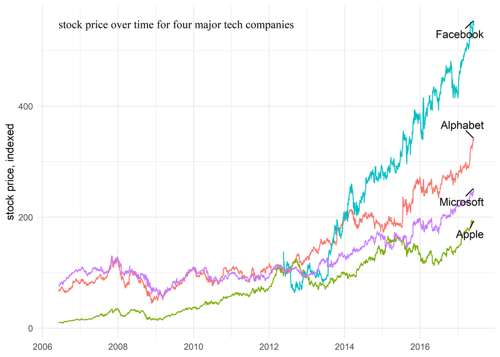

```r
label_info <- tech_stocks %>%
  arrange(desc(date)) %>%
  distinct(company, .keep_all = TRUE)

yrng <- range(tech_stocks$price_indexed)
xrng <- range(tech_stocks$date)
caption <- "stock price over time for four major tech companies"
ggplot(tech_stocks, aes(x = date, y = price_indexed)) +
  geom_line(aes(color = company), show.legend = FALSE)+
  geom_text_repel(data = label_info, aes(label = company), box.padding = 0.6, min.segment.length = 0, hjust = "right", seed = 9876) +
  annotate("text", x = xrng[1], y = yrng[2], label = caption, hjust = 0, vjust = 1,
           size = 4, family = "serif") +
  labs(x = NULL, y = "stock price, indexed") +
  theme_minimal()
```

## Exercise 3

Using the `titanic.rda` dataset, recreate the following graphic as precisely as possible.

*Hints:*

- Create a new variable that uses `died` and `survived` as levels/categories
- Hex colors: `#D55E00D0`, `#0072B2D0` (no alpha is being used)

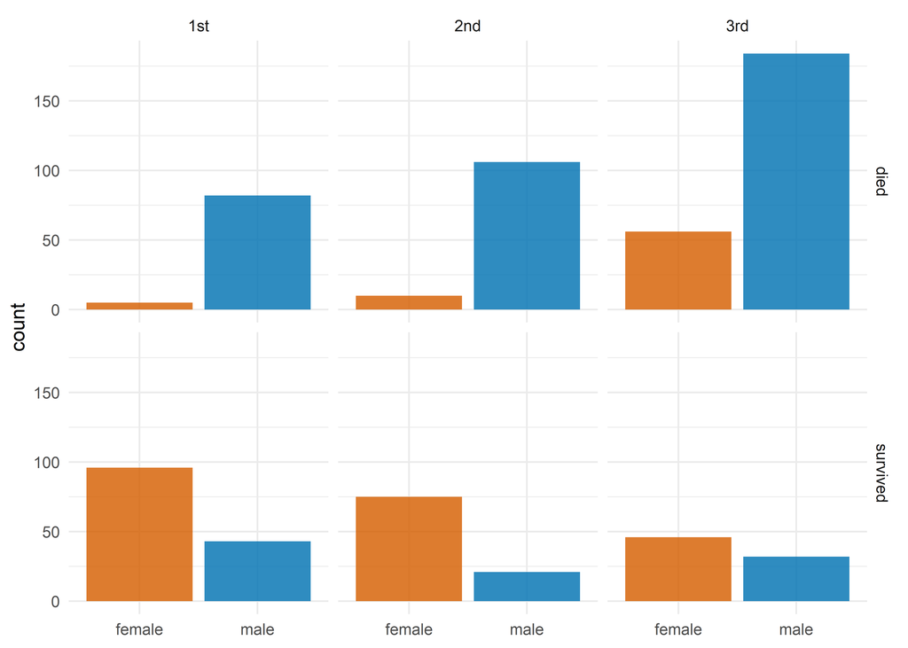

```r
titanic$status <- factor(titanic$survived, labels = c("died", "survived"))

ggplot(titanic, aes(sex, fill = sex)) +
  geom_bar(show.legend = FALSE) +
  facet_grid(cols = vars(class) , rows = vars(status)) +
  scale_fill_manual(values = c("#D55E00D0", "#0072B2D0")) +
  labs(x = NULL, y = "count") +
  theme_minimal()
```

## Exercise 4

Use the `athletes_dat` dataset — extracted from `Aus_althetes.rda` — to recreate the following graphic as precisely as possible. **Create the graphic twice**: once using `patchwork` and once using `cowplot`.

```r
# Get list of sports played by BOTH sexes
both_sports <- Aus_athletes |>
  # dataset of columns sex and sport
  # only unique observations
  distinct(sex, sport) |>
  # see if sport is played by one gender or both
  count(sport) |>
  # only want sports played by BOTH sexes
  filter(n == 2) |>
  # get list of sports
  pull(sport)

# Process data
athletes_dat <- Aus_athletes |>
  # only keep sports played by BOTH sexes
  filter(sport %in% both_sports) |>
  # rename track (400m) and track (sprint) to be track
  # case_when will be very useful with shiny apps
  mutate(
    sport = case_when(
      sport == "track (400m)" ~ "track",
      sport == "track (sprint)" ~ "track",
      TRUE ~ sport
      )
    )
```

*Hints:*

- Build each plot separately
- Bar plot: lower limit 0, upper limit 95
- Bar plot: shift bar labels by 5 units and top justify
- Bar plot: label size is 5
- Bar plot: `#D55E00D0` & `#0072B2D0` — no `alpha`
- Scatterplot: `#D55E00D0` & `#0072B2D0` — no `alpha`
- Scatterplot: filled circle with “white” outline; size is 3
- Scatterplot: `rcc` is red blood cell count; `wcc` is white blood cell count
- Boxplot: outline `#D55E00` and `#0072B2`; shading `#D55E0040` and `#0072B240`
- Boxplot: should be made narrower; 0.5
- Boxplot: Legend is in top-right corner of bottom plot
- Boxplot: Space out labels `c("female ", "male")`
- Boxplot: Legend shading matches hex values for top two plots

### Using `patchwork`

**TipSolution**

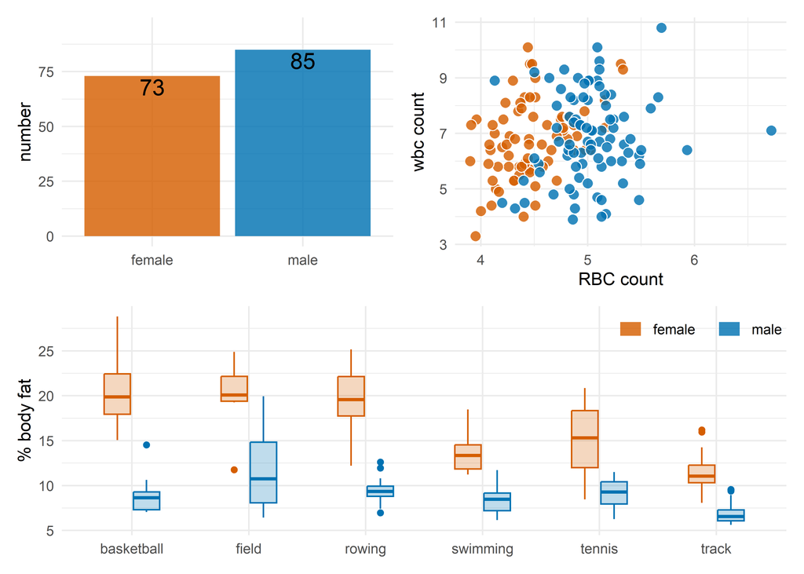

```r
p1 <- ggplot(athletes_dat, aes(sex, fill = sex)) +
  geom_bar(show.legend = FALSE) +
  geom_text(stat = "count", aes(label = after_stat(count), y = after_stat(count) -5), size = 5) +
  scale_x_discrete(labels = c("female", "male")) +
  scale_fill_manual(values = c("#D55E00D0", "#0072B2D0")) +
  labs(x = NULL, y = "number") +
  ylim(0, 95) +
  theme_minimal()

p2 <- ggplot(athletes_dat, aes(rcc, wcc, fill = sex)) +
  geom_point(size = 3, color = "white", shape = 21, show.legend = FALSE) +
  scale_fill_manual(values = c("#D55E00D0", "#0072B2D0")) +
  labs(x = "RBC count", y = "wbc count") +
  theme_minimal()

p3 <- ggplot(athletes_dat, aes(sport, pcBfat, color = sex, fill = sex)) +
  geom_boxplot(width = 0.5) +
  scale_fill_manual(values = c("#D55E0040", "#0072B240"), labels = c("female   ", "male"), name = NULL) +
  scale_color_manual(values = c("#D55E00", "#0072B2"), labels = c("female   ", "male")) +
  labs(x = NULL, y = "% body fat") +
  guides(color = "none", fill = guide_legend(override.aes = list(fill = c("#D55E00D0", "#0072B2D0"), color = NA))) +
  theme_minimal() +
  theme(legend.position = c(0.88, 0.90), legend.direction = "horizontal")

(p1 | p2)/p3
```

### Using `cowplot`

Use [`cowplot::plot_grid()`](https://wilkelab.org/cowplot/articles/plot_grid.html) to combine them.

**TipSolution**

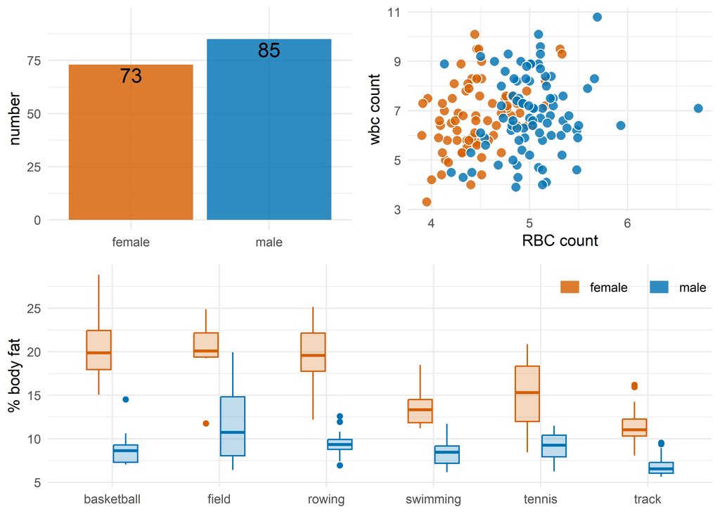

```r
plot_grid(plot_grid(p1,p2,nrow = 1), p3, ncol = 1)
```

## Exercise 5

Create the following graphic using `patchwork`.

*Hints:*

- Use plots created in Exercise 4
- inset theme is classic
  - Useful values: 0, 0.45, 0.75, 1
- plot annotation `"A"`

**TipSolution**

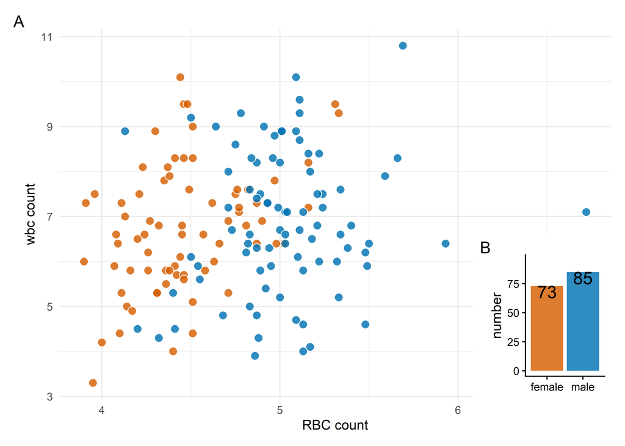

```r
p1 <- p1 + theme_classic()
p2 + inset_element(p1, left = 0.75, bottom = 0, right = 1, top = 0.45) + plot_annotation(tag_levels = "A")
```